# You get what you reinforce

Week 10 · Chapter 6 · Behaviorism and Social Cognitive Theory

Study · Week 10

Read Chapter 6 of the textbook (Eggen & Kauchak, 2025) before you read this brief. Unit 2 examined what happens inside a learner’s mind. Behaviorism sets the mind aside and asks a narrower question: what happens right after a behavior, and does the behavior come back? Social cognitive theory then brings the mind back into the explanation.

About 35 minutes: reading, two places you stop and write, and eight quick checks.

Pair this with **the Walkthrough**.

## Your own learning history

Chapter 6 describes things that have already happened to you. Because you have spent more than a decade in classrooms, begin with two memories:

- **A reward.** A teacher used a reward to change behavior, such as a sticker, extra recess, public praise or a grade. What behavior was it for? Did it work on you? Was there anyone it didn’t work for?
- **Something you learned by watching.** It might be a dance, a knot, or how a teacher handled an angry parent. Who did you watch, and why them? Were they skilled, popular, like you?

Keep both memories in mind, because every term below names something you have already experienced.

## A belief novice teachers may have

**Reward the behavior you want and you will get it.** This belief is true, and its truth creates a problem. You get *exactly* the behavior you reward, which is often different from the one you meant. The points chart in this week’s case rewards earning points, so Mila learned to earn points and Luis learned when to earn them.

Behaviorism gives you the tools to see what a system actually reinforces. Social cognitive theory adds what behaviorism leaves out, which is what each student expects and what students learn by watching each other.

## Behaviorism: learning as observable behavior

Behaviorism looks for observable, measurable laws of behavior. It asks what happened just before the behavior and what happened just after it. **Learning is a change in behavior**, and the teacher’s job is to arrange the environment so that the right changes happen.

## Classical conditioning

In classical conditioning, a neutral signal that is paired again and again with something that already produces a response comes to produce the response on its own (Pavlov, 1927).

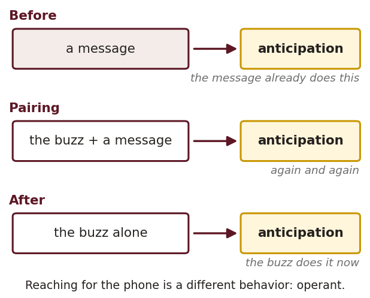

Classical conditioning in three steps. The buzz starts neutral and ends up producing the anticipation by itself.

Your phone The buzz (neutral) is paired with a message (which brings anticipation). Soon the buzz alone brings the anticipation, even when the message does not matter. Reaching for the phone is a separate behavior, and it is operant (see schedules below).

In class A teacher says *“take out a piece of paper”* only before pop quizzes, and soon the words alone produce anxiety. A coach shouts *“Get set!”* before every sprint, and soon the words alone make the heart race. A student smells formaldehyde during a dissection that upset them, and soon the smell alone makes them uneasy.

Nobody plans these associations. **Anxiety and avoidance are often conditioned**, which is why a student can dread a subject long after the teacher who caused it has gone.

True or false?

When your phone buzzes and you reach for it without thinking, the reach is classical conditioning.

Not quite The buzz brings the **anticipation**, and that feeling is the classical part. The reach is a behavior that sometimes pays off, so it is operant, kept going by a variable-ratio schedule.

Right The anticipation is classical. The reach is operant, because it is a behavior that sometimes pays off.

## Operant conditioning

Skinner (1953) studied what comes after a behavior. A behavior followed by a consequence becomes more likely or less likely to happen again. Two questions sort every consequence: is something **added** or **removed**, and does the behavior go **up** or **down**?

|  | **Up**: reinforcement | **Down**: punishment |
| --- | --- | --- |
| **+** added | Clean record, insurance discount. *A high-five after a great play.* | Speeding ticket. *Late to practice, extra laps.* |
| **−** removed | Buckle up, the beeping stops. *Perfect drill, no sprints.* | License suspended. *Argues with the ref, benched.* |

**“Negative” does not mean bad.** Positive (+) means *added*, and negative (−) means *taken away*. Chapter 6 also calls the two punishments **presentation punishment** (+) and **removal punishment** (−). Negative reinforcement is not punishment: when the seatbelt beep stops, buckling goes **up**. If the behavior increases, it was reinforced, whatever it felt like.

Extinction When a behavior is no longer reinforced, it fades. It usually gets worse first, in an **extinction burst**. A student who used to get attention by calling out calls out louder before they stop.

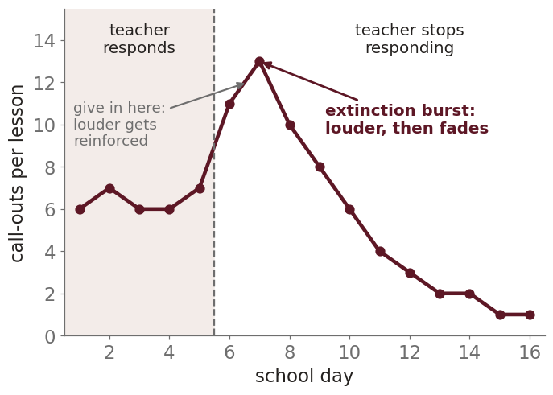

An extinction burst. When the teacher stops responding, calling out rises before it fades.

Shaping The teacher reinforces closer and closer versions of the target. A teacher who cannot wait for a reluctant writer to produce an essay reinforces the sentence, and then the paragraph.

Chaining, prompting, fading The teacher chains the steps of a routine (enter, sit, open the notebook, start the warm-up), prompts with a cue, and then **fades** the prompt until the routine runs without it. A prompt that never fades becomes part of the behavior.

True or false?

A teacher stops responding when a student calls out. If the plan is working, the calling out should drop right away.

Not quite Expect an **extinction burst** first, in which the calling out gets louder before it fades. A teacher who gives in during the burst reinforces louder calling out.

Right It usually gets worse before it gets better. Giving in during the burst teaches the student to call out louder.

## Schedules of reinforcement

*When* a reinforcer arrives matters as much as *whether* it arrives.

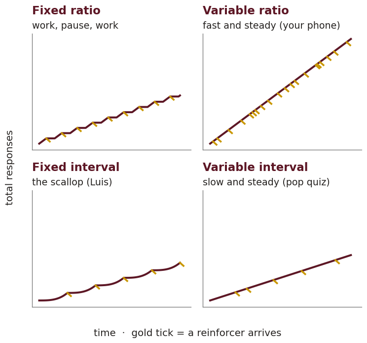

The four schedules as running totals of responses. A steeper line means faster responding, and a flat line means a pause.

Continuous The reinforcer arrives every time. The behavior is the fastest to learn and the fastest to fade when the reinforcer stops.

Fixed ratio · variable ratio The reinforcer arrives after a set number of responses, or after an unpredictable number. **Variable ratio produces the most persistent behavior there is**. Slot machines use it, and so does checking your phone, because any one check might pay off.

Fixed interval · variable interval The reinforcer arrives after a set time, or after an unpredictable time. A fixed interval produces a **scallop**, with little effort early and a rush just before the reinforcer, as when students study the night before a test scheduled weeks ago. A pop quiz is a variable interval, and it produces steadier effort.

Commit first

Luis scores 8/10 every week. He loses points Monday to Wednesday and earns them back Thursday and Friday. The totals are counted on Friday.

**Name the schedule Luis is responding to, and change one thing about the system that would flatten his week.** Explain why your change would work. Two or three sentences.

**Luis is responding to a fixed interval, and he is producing the scallop.** The reinforcer (the Friday total) arrives on a fixed day, and only the total counts. The earn-back rule adds to the effect, because points lost on Monday can be won back by Friday and nothing Luis does on Monday has a consequence that lasts. He found the schedule the system actually runs on. That is learning, and he is right to find it funny.

To flatten his week, change the schedule or the earn-back rule. You could make each day’s points final, check at unpredictable times (a variable interval), or cap how many points can be earned back. None of these changes asks Luis to try harder.

**Students learn the system’s schedule too, and they learn it faster than the content.**

## Applied behavior analysis: the function of a behavior

Applied behavior analysis (ABA) applies these principles to one student’s behavior. The teacher measures the behavior, changes the consequences, and measures again.

A-B-C **Antecedent** (what came just before) · **Behavior** (what the student did, described so two people would agree) · **Consequence** (what happened right after). A record of the three for a week shows the pattern.

Functional behavior assessment An FBA asks: **what does this behavior get the student?** The answer is usually attention, escape from a task, something tangible, or a sensory payoff. Two students can do the same thing for opposite reasons. A student who disrupts to get *out* of reading aloud is reinforced by being sent to the hall.

Token economies, contracts, group contingencies In a token economy, students exchange points or tokens for a reward later (the points chart is one). A **contingency contract** is an agreement with one student that connects a behavior with a reward. A **group contingency** rewards the class for what the class does, which turns peers into enforcers.

**How each one can fail.** A token economy reinforces *earning tokens*, which may not be the behavior you wanted (Mila), and tokens out of reach stop working (Michael). A public chart turns every score into a public judgment. A group contingency can make one student the reason everyone lost. When a teacher removes a behavior and leaves its cause in place, the cause comes back as a new behavior, and for this reason an FBA asks for function.

Check yourself

A sixth grader disrupts every time the class reads aloud. Each time, the teacher sends him to the hallway. The disruptions increase. For him, the hallway is:

Look at the behavior Punishment makes a behavior go *down*. The disruptions went up.

Yes Something was removed (reading aloud) and the behavior went up. An FBA asks what the behavior gets him, and here it gets him out of the room.

Something still follows the behavior Extinction means the reinforcer stops. Here every disruption still earns an exit.

He wanted to lose it Removal punishment takes away something the student values, and the behavior drops. He wanted out, and the disruptions rose.

## Limits of behaviorism

Behaviorism works, which is why it is still in every school. It also leaves out the inner world: beliefs, emotions, attention and memory, motivation, and **self-efficacy**. Reward systems carry a cost you will study in Week 11, because an external reward can undermine a task the learner already enjoyed.

Behaviorism explains two observations in the case only in part. Two students **stopped volunteering after watching Mila win**, although nothing happened to them, and Michael **turned down a free reset**. Behaviorism has an answer for each, and each answer leaves something out.

## Social cognitive theory

Bandura (1986) argued that learners are both **products and producers** of their environments. Two claims of his theory matter most here.

Learning without doing People learn by **observing** others and the consequences others get, so you do not have to be reinforced yourself.

Learning is not the same as behavior **We know things we don’t do.** A student can learn exactly how to get points and decide it is not worth it. Behaviorism does not account for that decision.

### Four steps of observational learning

| **Attention** | the learner has to notice the model |
| --- | --- |
| **Retention** | and remember what the model did |
| **Reproduction** | and be able to do it |
| **Motivation** | and expect it to be worth doing |

A student can fail at any of the four steps, and “They watched me do it” covers only the first.

True or false?

If students watched you model a skill carefully, they should now be able to do it.

Not quite Watching covers attention, and maybe retention. They still have to be able to **reproduce** it and expect it to be **worth doing**.

Right Watching is the first of four steps. Reproduction and motivation can still fail.

Vicarious reinforcement and punishment When people see someone else rewarded, the behavior becomes more likely in them. When they see someone else punished, it becomes less likely. **The case shows the opposite:** two students watched Mila win four times and volunteered *less*. The next two sections explain why.

### Who counts as a model

People imitate models they see as:

- **Similar** to themselves. A girl is more likely to choose engineering after watching a female engineer work.
- **Competent.** An aspiring golfer copies the accomplished golfer.
- **High status.** Teenagers wear what a pop star endorses. **This one is a problem:** high-status models get credited with expertise outside their field.

Mila is competent and high status on the chart, but to the two students who stopped volunteering she was **not similar**. Her wins told them what *Mila* could do and nothing about what they could do.

### Types and effects of models

Direct, symbolic, synthesized A **direct** model is a live person in the room, and a **symbolic** model is on a screen or in a book. A **synthesized** model is a learner’s own version, which combines pieces of several models. A player who studies two athletes on video and builds a jump shot from both is using symbolic models, synthesized.

Four outcomes of modeling Watching a model can teach a **new behavior**, **facilitate** a behavior the learner already has (everyone stands when one person stands), **change an inhibition** (one student stops whispering when the teacher hushes another), or **arouse an emotion** (a classmate’s anxiety before a test becomes yours).

Check yourself

In a quiet class, one student raises her hand to ask about the homework. Before the teacher answers her, three more students raise their hands with questions they already had. Which outcome of modeling is this?

They already knew how They already ask questions, so the model prompted the behavior and did not teach it.

Yes The behavior was already there. Her question worked as a cue for theirs, like everyone standing when one person stands.

Close An inhibition changes when the learner watches a **consequence** land on someone else. The teacher had not answered yet, so no consequence had happened.

No emotion is spreading Arousing an emotion would be her anxiety becoming theirs.

The nonoccurrence of an expected consequence When a learner expects a reward and it does not come, the missing reward works like a punisher. When they expect a punishment and it does not come, the missing punishment works like a reinforcer. The two students volunteered, expected it to count, and watched the bonus go to Mila again, so for them the missing reward worked like a punisher. **Expectation** is the concept that behaviorism lacks.

Commit first

A class is noisy, and the teacher says nothing to the room. She walks to a student who is quietly working, kneels down, and whispers, *“I love how focused you are, Sarah. Your pencil hasn’t stopped moving.”* The room gets quieter.

**Who was the message really for, and what did the rest of the class learn without anything happening to them?** Two or three sentences.

**The message was for the rest of the class.** Sarah was already working. The whisper is positive reinforcement for her, and **vicarious reinforcement** for everyone close enough to hear. They learned what earns the teacher’s attention in this room from a consequence delivered to someone else.

The strategy works because Sarah is a **similar** model, a classmate at the next desk who is doing something anyone in the room could do. It would work less well with the student who always wins. Remember this when you return to the case, in which two students stopped volunteering after watching Mila win, and nothing happened to them either.

### Reciprocal determinism

Person, behavior and environment each influence the other two. The chart (environment) influences Michael’s behavior, and his low scores influence what he expects (person). His expectation influences what he does, and what he does changes the environment, because the teacher offers a reset and the app flags him. A teacher can intervene at any one of the three.

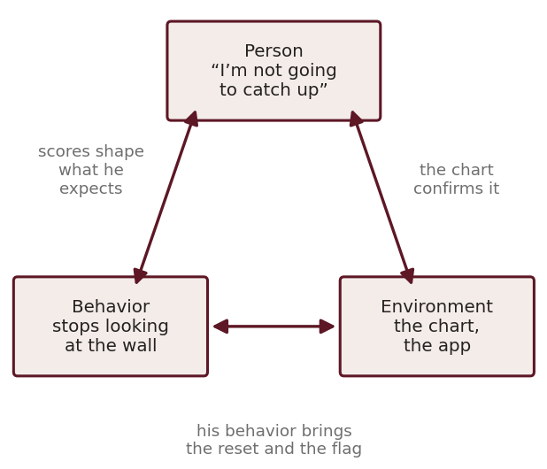

Reciprocal determinism, with Michael. Each corner influences the other two.

## Two ideas for the next weeks

Social cognitive theory has two more ideas, and this course gives each one a week.

Self-efficacy · Week 11 *“Points can be earned”* is an expectation about the outcome. *“I can earn them”* is a belief about yourself, and Bandura (1977) called it **self-efficacy**. Michael’s *“I’m not going to catch up”* sounds like the first and may be the second. Next week you will study where that belief comes from, alongside the other motivation theories.

Self-regulation · Week 12 When you count your phone checks this week, watch whether counting changes the count. For most people it does. This is **self-monitoring**, in which the learner takes over the job that the teacher’s consequences were doing. Week 12 builds it into lesson design.

## Reinforcement in AI

**Chatbots are shaped by reinforcement.** After a model has learned from large amounts of text, human raters compare its answers, and the model is reinforced toward the ones people prefer, which is operant conditioning at scale (Ouyang et al., 2022). Because people prefer answers that agree with them and praise them, models learn to agree and praise. Researchers call this **sycophancy** (Sharma et al., 2024). *“Great question!”* is a reinforced behavior.

This has two consequences for a tool you build:

- **Praise that does not depend on the answer is noise.** If the tool says *“Great thinking!”* to a wrong answer, praise stops carrying information. Only contingent, specific feedback teaches.
- **The tool is a model, and a high-status one.** It sounds fluent on every subject, so learners credit it with expertise everywhere, which is the status problem above. Learners learn to do what the tool does in front of them, such as writing the whole answer.

True or false?

A chatbot that praises every answer is reinforcing correct answers.

Not quite Praise for every answer depends on **answering**, so it reinforces answering and tells the learner nothing about correctness.

Right It reinforces answering. Praise teaches only when it depends on what the learner got right.

Your Friction Move this week (**Compare**) places a direct answer beside a guided one. In Step 5 you give the guided version a **wrong** answer on purpose and see what it praises.

## Two open questions

These questions have no answer key, and we will discuss them in class.

Two stories from this year introduce them. A **prediction market** is a legal app where people bet money on games, elections and the news. These apps take bets at 18, while most sportsbooks require 21, and addiction experts report college-age students getting hooked (Cohen & Buchwald, 2026). **Social media** is already in court. Families and school districts have sued Meta, the company behind Facebook and Instagram, saying its apps were designed to be addictive. In March 2026, the first jury to hear one of these cases found Meta and YouTube negligent in how they designed their platforms (NBC News, 2026).

1. **Why is it so hard to stop?** Use behaviorism to explain four things people struggle to put down: the phone, a social media feed, an AI chatbot that answers anything in seconds, and a prediction market. For each, name the schedule, how fast the consequence arrives, and what the notification has been paired with.
2. **A student tells you, “I can’t stop.”** Name one behavioral support a teacher could use. Explain what it changes: the antecedent, the consequence, or the behavior that takes its place.

*In person:* bring both Tuesday. *Online:* think them through this week.

## Check yourself

Check yourself

Mr. Lee’s class can take a five-minute break at the end of the period if they go twenty minutes without phones. Phone use drops, and students start reminding each other to put phones away. This is:

The phones stay with the students Nobody takes the phones. After the behavior, a break is **added**, and the behavior (twenty phone-free minutes) increases.

Look at what happens after the behavior Punishment would make the behavior *decrease*. The behavior that receives the consequence is going twenty minutes without phones, and it increased.

Yes Something was added (the break), the behavior went up, and the whole class earned it together. Students start reminding each other because a group contingency recruits peers.

No signal is being paired Classical conditioning pairs a neutral signal with a response the body already makes. Here a consequence follows a chosen behavior, so the learning is operant.

Check yourself

Jenna is learning a jump shot. Her coach has her watch videos of two professional players, one man and one woman. Her shot ends up mixing both techniques, and it looks more like the woman’s. The best explanation for *which* model she copied more is:

Both are stars Nothing in the case separates them on status or competence. The difference is Jenna.

No consequence is described Nobody rewarded either version, and she chose before anything followed. Behaviorism needs a consequence, and this case has none.

Yes The models have equal competence and equal status, so Jenna copies the one she sees herself in. Both players are **symbolic** models (on video), and her own blend is **synthesized** modeling.

Both models are symbolic Both are on video, so this can’t separate them.

By now you should **Have an answer to case question 1**, which explains in the chapter’s words what the chart reinforces in each of the four students.

**One behavior from your own classroom** that you would reinforce, the consequence you would use, and which of the four students it might produce instead.

**The models that brought you to teaching.** Who were they, and were they similar, competent, or high status? *In person:* bring it Thursday. *Online:* think it through this week.

*This week feeds Milestone 3: what your tool praises, how often, and what it models.*

## Sources

Bandura, A. (1977). Self-efficacy: Toward a unifying theory of behavioral change. *Psychological Review, 84*(2), 191–215.

Bandura, A. (1986). *Social foundations of thought and action: A social cognitive theory.* Prentice-Hall.

Cohen, M., & Buchwald, E. (2026, May 28). ‘The ads got to me’: College-age adults are rushing to prediction market sites. Addiction experts are alarmed. *CNN.* https://www.cnn.com/2026/05/28/economy/prediction-markets-kalshi-young-adults

Eggen, P. D., & Kauchak, D. P. (2025). *Using educational psychology in teaching* (12th ed.). Pearson. **This week: Chapter 6.**

NBC News. (2026, March 25). Jury finds Meta and YouTube negligent in landmark lawsuit on social media safety. https://www.nbcnews.com/tech/tech-news/verdict-reached-landmark-social-media-addiction-trial-rcna263421

Ouyang, L., Wu, J., Jiang, X., Almeida, D., Wainwright, C. L., Mishkin, P., … Lowe, R. (2022). Training language models to follow instructions with human feedback. *Advances in Neural Information Processing Systems, 35*, 27730–27744.

Pavlov, I. P. (1927). *Conditioned reflexes* (G. V. Anrep, Trans.). Oxford University Press.

Sharma, M., Tong, M., Korbak, T., Duvenaud, D., Askell, A., Bowman, S. R., … Perez, E. (2024). Towards understanding sycophancy in language models. *International Conference on Learning Representations.*

Skinner, B. F. (1953). *Science and human behavior.* Macmillan.